# Исследование объявлений о продаже квартир

В вашем распоряжении данные сервиса Яндекс.Недвижимость — архив объявлений о продаже квартир в Санкт-Петербурге и соседних населённых пунктах за несколько лет. Нужно научиться определять рыночную стоимость объектов недвижимости. Ваша задача — установить параметры. Это позволит построить автоматизированную систему: она отследит аномалии и мошенническую деятельность.

По каждой квартире на продажу доступны два вида данных. Первые вписаны пользователем, вторые получены автоматически на основе картографических данных. Например, расстояние до центра, аэропорта, ближайшего парка и водоёма.

## Комментарий ревьюера

Описание и план есть, теперь понятно, о чем будет проект!

## Изучение данных из файла

```python
import pandas as pd # импорт библиотеки
```

- Посмотрим данные приведенные в таблице
- Посмотрим характеристики таблицы, типы данных

```python
df = pd.read_csv('/datasets/real_estate_data.csv', sep='\t') # чтение файла
display(df.head(10)) # вывод первых 10 строк таблицы
```

|  | total_images | last_price | total_area | first_day_exposition | rooms | ceiling_height | floors_total | living_area | floor | is_apartment | ... | kitchen_area | balcony | locality_name | airports_nearest | cityCenters_nearest | parks_around3000 | parks_nearest | ponds_around3000 | ponds_nearest | days_exposition |
| --- | --- | --- | --- | --- | --- | --- | --- | --- | --- | --- | --- | --- | --- | --- | --- | --- | --- | --- | --- | --- | --- |
| 0 | 20 | 13000000.0 | 108.00 | 2019-03-07T00:00:00 | 3 | 2.70 | 16.0 | 51.00 | 8 | NaN | ... | 25.00 | NaN | Санкт-Петербург | 18863.0 | 16028.0 | 1.0 | 482.0 | 2.0 | 755.0 | NaN |
| 1 | 7 | 3350000.0 | 40.40 | 2018-12-04T00:00:00 | 1 | NaN | 11.0 | 18.60 | 1 | NaN | ... | 11.00 | 2.0 | посёлок Шушары | 12817.0 | 18603.0 | 0.0 | NaN | 0.0 | NaN | 81.0 |
| 2 | 10 | 5196000.0 | 56.00 | 2015-08-20T00:00:00 | 2 | NaN | 5.0 | 34.30 | 4 | NaN | ... | 8.30 | 0.0 | Санкт-Петербург | 21741.0 | 13933.0 | 1.0 | 90.0 | 2.0 | 574.0 | 558.0 |
| 3 | 0 | 64900000.0 | 159.00 | 2015-07-24T00:00:00 | 3 | NaN | 14.0 | NaN | 9 | NaN | ... | NaN | 0.0 | Санкт-Петербург | 28098.0 | 6800.0 | 2.0 | 84.0 | 3.0 | 234.0 | 424.0 |
| 4 | 2 | 10000000.0 | 100.00 | 2018-06-19T00:00:00 | 2 | 3.03 | 14.0 | 32.00 | 13 | NaN | ... | 41.00 | NaN | Санкт-Петербург | 31856.0 | 8098.0 | 2.0 | 112.0 | 1.0 | 48.0 | 121.0 |
| 5 | 10 | 2890000.0 | 30.40 | 2018-09-10T00:00:00 | 1 | NaN | 12.0 | 14.40 | 5 | NaN | ... | 9.10 | NaN | городской посёлок Янино-1 | NaN | NaN | NaN | NaN | NaN | NaN | 55.0 |
| 6 | 6 | 3700000.0 | 37.30 | 2017-11-02T00:00:00 | 1 | NaN | 26.0 | 10.60 | 6 | NaN | ... | 14.40 | 1.0 | посёлок Парголово | 52996.0 | 19143.0 | 0.0 | NaN | 0.0 | NaN | 155.0 |
| 7 | 5 | 7915000.0 | 71.60 | 2019-04-18T00:00:00 | 2 | NaN | 24.0 | NaN | 22 | NaN | ... | 18.90 | 2.0 | Санкт-Петербург | 23982.0 | 11634.0 | 0.0 | NaN | 0.0 | NaN | NaN |
| 8 | 20 | 2900000.0 | 33.16 | 2018-05-23T00:00:00 | 1 | NaN | 27.0 | 15.43 | 26 | NaN | ... | 8.81 | NaN | посёлок Мурино | NaN | NaN | NaN | NaN | NaN | NaN | 189.0 |
| 9 | 18 | 5400000.0 | 61.00 | 2017-02-26T00:00:00 | 3 | 2.50 | 9.0 | 43.60 | 7 | NaN | ... | 6.50 | 2.0 | Санкт-Петербург | 50898.0 | 15008.0 | 0.0 | NaN | 0.0 | NaN | 289.0 |

10 rows × 22 columns

```python
df.info() # вывод данных о таблице
```

```
<class 'pandas.core.frame.DataFrame'>
RangeIndex: 23699 entries, 0 to 23698
Data columns (total 22 columns):
total_images            23699 non-null int64
last_price              23699 non-null float64
total_area              23699 non-null float64
first_day_exposition    23699 non-null object
rooms                   23699 non-null int64
ceiling_height          14504 non-null float64
floors_total            23613 non-null float64
living_area             21796 non-null float64
floor                   23699 non-null int64
is_apartment            2775 non-null object
studio                  23699 non-null bool
open_plan               23699 non-null bool
kitchen_area            21421 non-null float64
balcony                 12180 non-null float64
locality_name           23650 non-null object
airports_nearest        18157 non-null float64
cityCenters_nearest     18180 non-null float64
parks_around3000        18181 non-null float64
parks_nearest           8079 non-null float64
ponds_around3000        18181 non-null float64
ponds_nearest           9110 non-null float64
days_exposition         20518 non-null float64
dtypes: bool(2), float64(14), int64(3), object(3)
memory usage: 3.7+ MB
```

В таблице 22 столбца, 23699 строк.

Определение названий столбцов:

- airports_nearest — расстояние до ближайшего аэропорта в метрах (м)
- balcony — число балконов
- ceiling_height — высота потолков (м)
- cityCenters_nearest — расстояние до центра города (м)
- days_exposition — сколько дней было размещено объявление (от публикации до снятия)
- first_day_exposition — дата публикации
- floor — этаж
- floors_total — всего этажей в доме
- is_apartment — апартаменты
- kitchen_area — площадь кухни в квадратных метрах (м²)
- last_price — цена на момент снятия с публикации
- living_area — жилая площадь в квадратных метрах (м²)
- locality_name — название населённого пункта
- open_plan — свободная планировка
- parks_around3000 — число парков в радиусе 3 км
- parks_nearest — расстояние до ближайшего парка (м)
- ponds_around3000 — число водоёмов в радиусе 3 км
- ponds_nearest — расстояние до ближайшего водоёма (м)
- rooms — число комнат
- studio — квартира-студия
- total_area — площадь квартиры в квадратных метрах (м²)
- total_images — число фотографий квартиры в объявлении

Данные столбцов "свободная планировка", "квартира-студия" относятся к булевому типу данных. Данные столбцов "дата публикации", "апартаменты", "название населенного пункта" относятся к разным типам данных. Данные столбцов "число фотографий квартиры", "число комнат", "этаж" относятся к целочисленному типу данных. Данные остальных столбцов относятся к вещественному типу данных.

### Вывод

В каждой строке таблицы — данные о продаже квартиры и о её характеристиках.

Предварительно можно утверждать, что, данных достаточно. Но встречаются пропуски в данных, а в названиях колонок — расхождения с хорошим стилем.

## Предобработка данных

В данном разделе необходимо:

- скоррективать внешний вид таблицы
- найти/устранить пропуски
- убрать из даты публицикации время
- изменить где требуется типы данных
- найти/удалить дубликаты

```python
display(df.isna().sum()) # вывод количества пропусков по столбцам
```

```
total_images                0
last_price                  0
total_area                  0
first_day_exposition        0
rooms                       0
ceiling_height           9195
floors_total               86
living_area              1903
floor                       0
is_apartment            20924
studio                      0
open_plan                   0
kitchen_area             2278
balcony                 11519
locality_name              49
airports_nearest         5542
cityCenters_nearest      5519
parks_around3000         5518
parks_nearest           15620
ponds_around3000         5518
ponds_nearest           14589
days_exposition          3181
dtype: int64
```

Итак, изучим пропуски:

- "высота потолка" -скорее всего, пропущены значение стандартной высоты потолков, так как наверняка продавец указал бы высоту потолка будь она нестандартной. Предполагаю пустые значения заполнить медианой.
- "всего этажей в доме" - считаю, что здесь не нужно заполнять пропуски, нет параметров по которым мы могли бы судить о высоте дома.
- "жилая площадь" -считаю, что здесь не нужно заполнять пропуски, нет параметров по которым мы могли бы судить о жилой площади квартиры.
- "апартаменты" - пропусков много, предполагаю, что пропущенное значение, значит статус "жилого помещения", так как в основном в нашей стране превалирует жилой фонд. Заполним пропуски значением False.
- "площадь кухни" - считаю, что здесь не нужно заполнять пропуски, нет параметров по которым мы могли бы судить о площади кухни.
- "балконы" - пропусков много, предполагаю, что пропущенное значение, значит что балкон отсутствует. Заполним пропуски значением False.
- "наименование населенного пункта" - строки, в которых пропущены значения "название населенного пункта", удалим, так как в исследовании эти данные важныб а запонить из не представлю возможным. Пропущенные строки составляют 0,2% от объема всех строк таблицы данных.
- расстояние до ближайшего аэропорта в метрах (м) - пропусков много, но они заполняются на основе картографических данных автоматически. Предполагаю, что расстояния до аэропорта не указано для маленьких посёлков, где этот параметр никак не влияет на стоимость жилья.(может быть этих адресов нет на карте, или дорог, что яндекс-карты не смогли вычислить расстояние). Считаю, что не нужно заполнять эти пропуски, так как медианное значение будет не корректно искажать результаты исследования.
- "расстояние до центра города"- пропусков много, примерно тоже количество что и в предыдущем пункте, предположим те же самые причины пропусков.Считаю, что не нужно заполнять эти пропуски, так как медианное значение будет не корректно искажать результаты исследования.
- "расстояние до ближайшего парка" - пропусков много, предположу что данная характеристика не актуальна для малых населенных пунктов. Считаю, что не нужно заполнять эти пропуски, так как медианное значение будет не корректно искажать результаты исследования.
- "число парков в радиусе 3000 м "- пропусков много, примерно тоже количество, что и в предыдущем пункте, предположим те же самые причины пропусков. Считаю, что не нужно заполнять эти пропуски, так как медианное значение будет не корректно искажать результаты исследования.
- "число водоемов в радиусе 3000 м"- пропусков много, предположу что данная характеристика не актуальна для малых населенных пунктов. Считаю, что не нужно заполнять эти пропуски, так как медианное значение будет не корректно искажать результаты исследования.
- "расстояние до водоема" - пропусков много, предположу что данная характеристика не актуальна для малых населенных пунктов. Считаю, что не нужно заполнять эти пропуски, так как медианное значение будет не корректно искажать результаты исследования.
- "сколько дней было размещено объявление" - есть пропуски, не считаю возможным их заполнить.

```python
print(df['ceiling_height'].median()) # расчет средней высоты потолка(похоже на правдивое значение)
```

```
2.65
```

```python
df['ceiling_height'] = df['ceiling_height'].fillna(df['ceiling_height'].median()) # заменяем пропущенные значения высоты потолка медианой
```

## Комментарий ревьюера

В этом месте давай подумаем вместе: можем ли мы быть на 100% уверены, что пропуски высоты потолков случайны? Может быть у продавцов есть какая-то причина, по которой они не акцентируют внимание на потолках ;)?

На мой взгляд лучшим решением было бы не заполнять пропуски в этом признаке, но последнее слово за тобой.

И хочу посоветовать тебе статью, которая рассматривает разные способы обработки пропусков, выделяет их плюсы и минусы, думаю, тебе может быть интересно: https://loginom.ru/blog/missing

```python
print(df['is_apartment'].unique()) # посмотрим какими значениями заполнили столбец "апартаменты"
```

```
[nan False True]
```

```python
df['is_apartment'] = df['is_apartment'].fillna(False) # заменили пропуски в столбце "апартаменты"
```

```python
print(df['balcony'].unique()) # посмотрим какими значениями заполнили столбец "балконы"
```

```
[nan  2.  0.  1.  5.  4.  3.]
```

```python
print(df['balcony'].value_counts())# подсчёт уникальных значений столбца "балконы"
```

```
1.0    4195
0.0    3758
2.0    3659
5.0     304
4.0     183
3.0      81
Name: balcony, dtype: int64
```

```python
df['balcony'] = df['balcony'].fillna(0) #заменим пропущенные значения на 0
```

Строки, в которых пропущены значения "название населенного пункта", удалим, так как в исследовании эти данные важны. Пропущенные строки составляют 0,2% от объема всех строк таблицы данных.

```python
df = df.dropna(subset=['locality_name']) # удалим строки, где не указано название населенного пункта
```

Проверим, возможно ли в нашем исследовании заполнять пропуски по расстоянию до аэропорта, расстоянию до водоемов и тд

```python
top_10 = df.groupby('locality_name')['locality_name'].count().sort_values(ascending = False) #сортируем по названиям населенных пунктов, считаем и сортируем по убыванию
display(top_10.head(10))
top_10_name = df.query('locality_name == "Санкт-Петербург" or locality_name == "посёлок Мурино"')# срез по двум населенным пунктам, где больше всего объявлений
print(top_10_name.isna().sum()) # количество пропусков для топ 2 населенных пунктов
```

```
locality_name
Санкт-Петербург      15721
посёлок Мурино         522
посёлок Шушары         440
Всеволожск             398
Пушкин                 369
Колпино                338
посёлок Парголово      327
Гатчина                307
деревня Кудрово        299
Выборг                 237
Name: locality_name, dtype: int64
```

```
total_images               0
last_price                 0
total_area                 0
first_day_exposition       0
rooms                      0
ceiling_height             0
floors_total              72
living_area             1201
floor                      0
is_apartment               0
studio                     0
open_plan                  0
kitchen_area            1479
balcony                    0
locality_name              0
airports_nearest         607
cityCenters_nearest      583
parks_around3000         583
parks_nearest           8959
ponds_around3000         583
ponds_nearest           8260
days_exposition         2088
dtype: int64
```

Делаю вывод, что вряд ли для города Санкт-Петербург и для поселка Мурино не определяется расстояние до аэропорта. Явно ошибка не из-за картографических данных, и соответственно, не получится заменить пропуски в подобных данных столбцах.

Поработаем с внешним видом таблицы:

- приведем к нижнему регистру названия столбцов и данные с названиями населенных пунктов, добавим "змеиный" регистр.

```python
df['locality_name'] = df['locality_name'].str.lower() # приведем к нижнему регистру названия населенных пунктов
```

```python
df = df.rename(columns = {'cityCenters_nearest': 'city_сenters_nearest', 'parks_around3000': 'parks_around_3000', 'ponds_around3000': 'ponds_around_3000'})
# переименование столбцов
```

Уберем из даты публикации время. Переведем данные столбца к типу данных datetime с помощью метода to_datetime()

```python
# перевод к типу данных datetime
df['first_day_exposition'] = pd.to_datetime(df['first_day_exposition'], format='%Y-%m-%dT%H:%M:%S') # 2019-03-07T00:00:00
```

Переведем в целочисленный тип данных следующие столбцы с помощью цикла. Количество балконов, парков, водоемов, дней публикации являются целвми числами и не могут быть вещественными, данные по расстояниям удобнее воспринимать целым числом, без дробной части

```python
columns = ['last_price', 'floors_total', 'balcony', 'airports_nearest', 'city_сenters_nearest', 'parks_around_3000', 'parks_nearest', 'ponds_around_3000', 'ponds_nearest', 'days_exposition']

for column in columns:
    try:
        df[column] = df[column].astype('float32').astype('Int64')
    except:
        print('oq')
```

```python
df.info() # проверим изменились ли типы данных
```

```
<class 'pandas.core.frame.DataFrame'>
Int64Index: 23650 entries, 0 to 23698
Data columns (total 22 columns):
total_images            23650 non-null int64
last_price              23650 non-null Int64
total_area              23650 non-null float64
first_day_exposition    23650 non-null datetime64[ns]
rooms                   23650 non-null int64
ceiling_height          23650 non-null float64
floors_total            23565 non-null Int64
living_area             21752 non-null float64
floor                   23650 non-null int64
is_apartment            23650 non-null bool
studio                  23650 non-null bool
open_plan               23650 non-null bool
kitchen_area            21381 non-null float64
balcony                 23650 non-null Int64
locality_name           23650 non-null object
airports_nearest        18116 non-null Int64
city_сenters_nearest    18139 non-null Int64
parks_around_3000       18140 non-null Int64
parks_nearest           8064 non-null Int64
ponds_around_3000       18140 non-null Int64
ponds_nearest           9085 non-null Int64
days_exposition         20470 non-null Int64
dtypes: Int64(10), bool(3), datetime64[ns](1), float64(4), int64(3), object(1)
memory usage: 3.9+ MB
```

```python
df.head()
```

|  | total_images | last_price | total_area | first_day_exposition | rooms | ceiling_height | floors_total | living_area | floor | is_apartment | ... | kitchen_area | balcony | locality_name | airports_nearest | city_сenters_nearest | parks_around_3000 | parks_nearest | ponds_around_3000 | ponds_nearest | days_exposition |
| --- | --- | --- | --- | --- | --- | --- | --- | --- | --- | --- | --- | --- | --- | --- | --- | --- | --- | --- | --- | --- | --- |
| 0 | 20 | 13000000 | 108.0 | 2019-03-07 | 3 | 2.70 | 16 | 51.0 | 8 | False | ... | 25.0 | 0 | санкт-петербург | 18863 | 16028 | 1 | 482 | 2 | 755 | NaN |
| 1 | 7 | 3350000 | 40.4 | 2018-12-04 | 1 | 2.65 | 11 | 18.6 | 1 | False | ... | 11.0 | 2 | посёлок шушары | 12817 | 18603 | 0 | NaN | 0 | NaN | 81 |
| 2 | 10 | 5196000 | 56.0 | 2015-08-20 | 2 | 2.65 | 5 | 34.3 | 4 | False | ... | 8.3 | 0 | санкт-петербург | 21741 | 13933 | 1 | 90 | 2 | 574 | 558 |
| 3 | 0 | 64900000 | 159.0 | 2015-07-24 | 3 | 2.65 | 14 | NaN | 9 | False | ... | NaN | 0 | санкт-петербург | 28098 | 6800 | 2 | 84 | 3 | 234 | 424 |
| 4 | 2 | 10000000 | 100.0 | 2018-06-19 | 2 | 3.03 | 14 | 32.0 | 13 | False | ... | 41.0 | 0 | санкт-петербург | 31856 | 8098 | 2 | 112 | 1 | 48 | 121 |

5 rows × 22 columns

Проверим таблицу на наличие дубликатов. Дубликатов нет.

```python
display(df.duplicated().sum()) # подсчет количества явных дубликатов
```

```
0
```

### Вывод

Целью предобработки данных была подготовка данных к исследованию.

1. Были заполенены пропуски в тех столбцах, где это было логично и реально сделать.
2. Были изменены типы данных, и их вид для лучшего восприятия и обработки.

## Расчёты и добавление результатов в таблицу

Расчет стоимости квадратного метра и добавление этих данных в таблицу:

```python
df['m2_price'] = df['last_price'] / df['total_area'] # стоимость квадратного метра
df['m2_price'] = df['m2_price'].astype('int') # перевод в целочисленный тип данных
```

Добавим в таблицу столбцы день, месяц и год публикации объявления

```python
df['day_weeks'] = pd.DatetimeIndex(df['first_day_exposition']).weekday # добавление нового столбца в таблицу "день недели"
df['month'] = pd.DatetimeIndex(df['first_day_exposition']).month # добавление нового столбца в таблицу "месяц"
df['year'] = pd.DatetimeIndex(df['first_day_exposition']).year # добавление нового столбца в таблицу "год"
df.head()
```

|  | total_images | last_price | total_area | first_day_exposition | rooms | ceiling_height | floors_total | living_area | floor | is_apartment | ... | city_сenters_nearest | parks_around_3000 | parks_nearest | ponds_around_3000 | ponds_nearest | days_exposition | m2_price | day_weeks | month | year |
| --- | --- | --- | --- | --- | --- | --- | --- | --- | --- | --- | --- | --- | --- | --- | --- | --- | --- | --- | --- | --- | --- |
| 0 | 20 | 13000000 | 108.0 | 2019-03-07 | 3 | 2.70 | 16 | 51.0 | 8 | False | ... | 16028 | 1 | 482 | 2 | 755 | NaN | 120370 | 3 | 3 | 2019 |
| 1 | 7 | 3350000 | 40.4 | 2018-12-04 | 1 | 2.65 | 11 | 18.6 | 1 | False | ... | 18603 | 0 | NaN | 0 | NaN | 81 | 82920 | 1 | 12 | 2018 |
| 2 | 10 | 5196000 | 56.0 | 2015-08-20 | 2 | 2.65 | 5 | 34.3 | 4 | False | ... | 13933 | 1 | 90 | 2 | 574 | 558 | 92785 | 3 | 8 | 2015 |
| 3 | 0 | 64900000 | 159.0 | 2015-07-24 | 3 | 2.65 | 14 | NaN | 9 | False | ... | 6800 | 2 | 84 | 3 | 234 | 424 | 408176 | 4 | 7 | 2015 |
| 4 | 2 | 10000000 | 100.0 | 2018-06-19 | 2 | 3.03 | 14 | 32.0 | 13 | False | ... | 8098 | 2 | 112 | 1 | 48 | 121 | 100000 | 1 | 6 | 2018 |

5 rows × 26 columns

Поделим варианты этажей на три категории: первый, последний, другой. Для этого напишем функцию, которая будет возвращать категорию этажа и применим ее к таблице. Добавим новый столбец в таблицу

```python
def floor(row): # функция, которая возращает категорию этажа
    if row['floor'] == 1:
        return 'первый'
    if row['floor'] == row['floors_total']:
        return 'последний'
    return 'другой'
```

```python
df['floor_category'] = df.apply(floor, axis=1) # добавление нового столбца в таблицу "категория этажа"
```

Добавим столбцы соотношение жилой площади к общей площади, соотношение площади кухни к общей площади

```python
df['area_living_total'] = df['living_area'] / df['total_area'] # добавим столбец соотношение жилой площади к общей площади
```

```python
df['area_kitchen_total'] = df['kitchen_area'] / df['total_area'] # добавим столбец соотношение площади кухни к общей площади
```

```python
display(df.head(10))
```

|  | total_images | last_price | total_area | first_day_exposition | rooms | ceiling_height | floors_total | living_area | floor | is_apartment | ... | ponds_around_3000 | ponds_nearest | days_exposition | m2_price | day_weeks | month | year | floor_category | area_living_total | area_kitchen_total |
| --- | --- | --- | --- | --- | --- | --- | --- | --- | --- | --- | --- | --- | --- | --- | --- | --- | --- | --- | --- | --- | --- |
| 0 | 20 | 13000000 | 108.00 | 2019-03-07 | 3 | 2.70 | 16 | 51.00 | 8 | False | ... | 2 | 755 | NaN | 120370 | 3 | 3 | 2019 | другой | 0.472222 | 0.231481 |
| 1 | 7 | 3350000 | 40.40 | 2018-12-04 | 1 | 2.65 | 11 | 18.60 | 1 | False | ... | 0 | NaN | 81 | 82920 | 1 | 12 | 2018 | первый | 0.460396 | 0.272277 |
| 2 | 10 | 5196000 | 56.00 | 2015-08-20 | 2 | 2.65 | 5 | 34.30 | 4 | False | ... | 2 | 574 | 558 | 92785 | 3 | 8 | 2015 | другой | 0.612500 | 0.148214 |
| 3 | 0 | 64900000 | 159.00 | 2015-07-24 | 3 | 2.65 | 14 | NaN | 9 | False | ... | 3 | 234 | 424 | 408176 | 4 | 7 | 2015 | другой | NaN | NaN |
| 4 | 2 | 10000000 | 100.00 | 2018-06-19 | 2 | 3.03 | 14 | 32.00 | 13 | False | ... | 1 | 48 | 121 | 100000 | 1 | 6 | 2018 | другой | 0.320000 | 0.410000 |
| 5 | 10 | 2890000 | 30.40 | 2018-09-10 | 1 | 2.65 | 12 | 14.40 | 5 | False | ... | NaN | NaN | 55 | 95065 | 0 | 9 | 2018 | другой | 0.473684 | 0.299342 |
| 6 | 6 | 3700000 | 37.30 | 2017-11-02 | 1 | 2.65 | 26 | 10.60 | 6 | False | ... | 0 | NaN | 155 | 99195 | 3 | 11 | 2017 | другой | 0.284182 | 0.386059 |
| 7 | 5 | 7915000 | 71.60 | 2019-04-18 | 2 | 2.65 | 24 | NaN | 22 | False | ... | 0 | NaN | NaN | 110544 | 3 | 4 | 2019 | другой | NaN | 0.263966 |
| 8 | 20 | 2900000 | 33.16 | 2018-05-23 | 1 | 2.65 | 27 | 15.43 | 26 | False | ... | NaN | NaN | 189 | 87454 | 2 | 5 | 2018 | другой | 0.465320 | 0.265682 |
| 9 | 18 | 5400000 | 61.00 | 2017-02-26 | 3 | 2.50 | 9 | 43.60 | 7 | False | ... | 0 | NaN | 289 | 88524 | 6 | 2 | 2017 | другой | 0.714754 | 0.106557 |

10 rows × 29 columns

## Исследовательский анализ данных

Изучим следующие параметры: площадь, цена, число комнат, высота потолков. Постройте гистограммы для каждого параметра.

1. Изучим данные по площадям квартир: максимальная площадь 900, минимальная 12, средняя 60.

```python
df['total_area'].describe() # выведем статистику по столбцу "общая площадь"
```

```
count    23650.000000
mean        60.329069
std         35.661808
min         12.000000
25%         40.000000
50%         52.000000
75%         69.700000
max        900.000000
Name: total_area, dtype: float64
```

Средняя площадь квартиры -60 квадратов, медианная площадь составляет 52 квадратных метра.

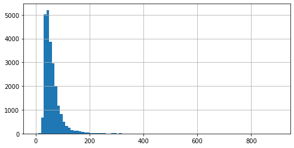

```python
df['total_area'].hist(bins=90, range=(0, 900),figsize=(8,4)) # гистограмма площади квартир
```

Из гистограммы и статистики можно сделать вывод, что площадь 900 выброс и из-за того что в параметрах гистограммы учитывается это значение, гистограмма становится плохочитаемой и сложно сделать какие- либо выводы. В следующем шаге поменяю параметры гистограммы.

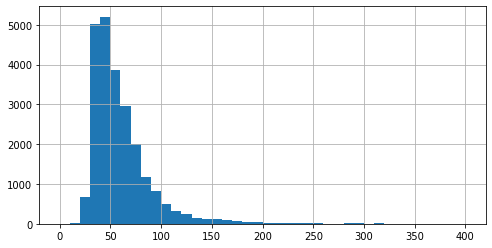

```python
df['total_area'].hist(bins=40, range=(0, 400),figsize=(8,4)) # гистограмма площади квартир
```

По данной диаграмме можно сделать вывод, что большинство продаваемых квартир имеют площадь от 40 до 50 квадратных метров. Вторая группа по количеству объявлений это квартиры с площадью от 30 до 40 квадратных метров. Третье место занимаю квартиры с площадью от 50 до 60 квадратов. И далее по убыванию: чем больше площадь тем меньше таких предложений на рынке продажи.

1. Изучим данные по цене квартир

```python
df['last_price'].describe()# выведем статистику по столбцу " цена"
```

```
count    2.365000e+04
mean     6.541127e+06
std      1.089640e+07
min      1.219000e+04
25%      3.400000e+06
50%      4.650000e+06
75%      6.799000e+06
max      7.630000e+08
Name: last_price, dtype: float64
```

Медианная стоимость 4,65 мил., средняя стоимость -6.54 мил.

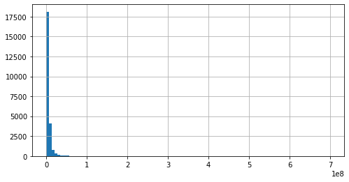

```python
df['last_price'].hist(bins=100, range=(0, 7e8), figsize=(8,4)) # гистограмма цены квартир
```

По данной гистограмме сложно сделать какой- либо вывод. Попробую поменять аргументы, отбросив максимальной значение, так как квартир по максимальной стоимости совсем мало.

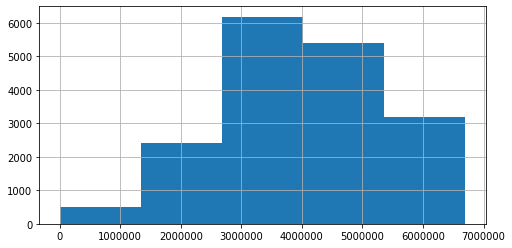

```python
df['last_price'].hist(bins=5, range=(0, 6.7e6), figsize=(8,4)) # гистограмма цены квартир
```

По данной гистограмме можно сделать вывод: большинство продающихся квартир в ценовом диапазоне-от 2,7 до 4 мил.рублей, второе место у квартир стоимостью от 4 до 5,3 мил руб, третье место по количество квартиры в ценовом диапазоне от 5,3 до 6,8 мил.рублей.

1. Изучим столбец "количество комнат"

```python
df['rooms'].describe() # выведем статистику по столбцу "количество комнат"
```

```
count    23650.000000
mean         2.070106
std          1.078620
min          0.000000
25%          1.000000
50%          2.000000
75%          3.000000
max         19.000000
Name: rooms, dtype: float64
```

Среднее количество комнат- 2. Среднее и медианное значение практически совпадают, хотя есть выброс 19, но он особо не влияет на статистику.

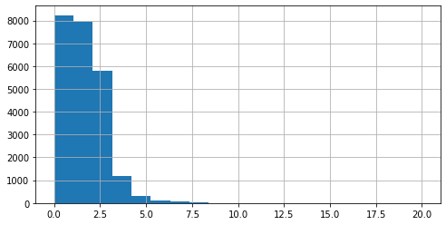

```python
df['rooms'].hist(bins=19, range=(0, 20), figsize=(8,4)) # гистограмма по количеству комнат
```

Из гистограммы можем сделать вывод, что большинство квартир с одной комнатой, и далее по убыванию чем больше комнат, тем меньше таких квартир продается

1. Изучим столбец "высота потолков"

```python
df['ceiling_height'].describe()# выведем статистику по столбцу " высота потолков"
```

```
count    23650.000000
mean         2.724311
std          0.989255
min          1.000000
25%          2.600000
50%          2.650000
75%          2.700000
max        100.000000
Name: ceiling_height, dtype: float64
```

Среднее 2.7 м, что практически совпадает с медианой. Максимальное значение 100 м, минимальное - 1 м видимо присутствует ошибка в заполнении данных

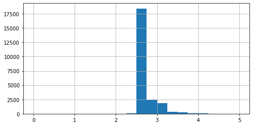

```python
df['ceiling_height'].hist(bins=20, range=(0, 5), figsize=(8,4)) # гистограмма по высоте потолка
```

Из гистограммы видно, что большинство квартир имеют среднюю высоту потолка в 2.7 м

```python
# код ревьюера

df['ceiling_height'].value_counts()
```

```
2.65      9836
2.50      3515
2.60      1645
2.70      1572
3.00      1109
          ...
3.98         1
4.65         1
5.80         1
4.90         1
100.00       1
Name: ceiling_height, Length: 183, dtype: int64
```

1. Изучим время продажи квартир

```python
df['days_exposition'].describe() # выведем статистику по столбцу " количество дней продажи"
```

```
count    20470.000000
mean       180.753200
std        219.777916
min          1.000000
25%         45.000000
50%         95.000000
75%        231.000000
max       1580.000000
Name: days_exposition, dtype: float64
```

Максимальное время продажи 1580 дней, минимальное 1 день. Медианное время продажи составляет 95 дней, то есть обычно квартира продается примерно за 3 месяца.

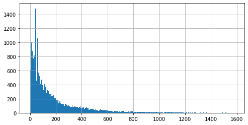

```python
df['days_exposition'].hist(bins=230, range=(0, 1580), figsize=(8,4)) # гистограмма по количеству дней продажи
```

По гистограмме видно, что большинство квартир были проданы примерно за 50 дней.

1. Из полученных данных уберем выбивающиеся значения:
- общая площадь 300 квадратных метров # было 900, стало 300
- стоимость составляет 7.630000e+08
- количество комнат 10 шт # было 19, стало 10
- высота потолка от 2.5 до 4 метров, # было <100 м
- максимальное время продажи 1580 и минимальное время продажи 1 день

df.columns

```python
#df_filtered = df[df['total_area'] < 900]
#df_filtered = df_filtered[df_filtered['last_price'] < 763000000]
#df_filtered = df_filtered[df_filtered['rooms'] < 19]
#df_filtered = df_filtered[df_filtered['ceiling_height'] < 100]
#df_filtered = df_filtered[1 < df_filtered['days_exposition'] < 1580]

df_filtered = df.query('total_area < 300')
df_filtered = df_filtered.query('last_price < 763000000')
df_filtered = df_filtered.query('rooms < 10')
df_filtered = df_filtered.query('2.5 <= ceiling_height <= 4')
df_filtered = df_filtered.query('1 < days_exposition < 1580')





#df_filtered = df.query('total_area < 300 or last_price < 763000000 or rooms < 10 or 2.65 < ceiling_height < 3 or 1 < days_exposition < 1580')
```

Посмотрим как поменялась этих параметров после фильтрования от выбивающихся значений

```python
df_filtered['total_area'].describe() #статистика по общей площади
```

```
count    20294.000000
mean        57.917726
std         28.870580
min         12.000000
25%         39.412500
50%         50.700000
75%         67.500000
max        297.500000
Name: total_area, dtype: float64
```

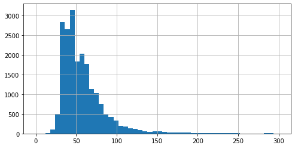

```python
df_filtered['total_area'].hist(bins=50, range=(0, 300),figsize=(8,4))  # гистограмма по общей площади
```

```python
df_filtered['last_price'].describe() #статистика по цене
```

```
count    2.029400e+04
mean     5.999011e+06
std      7.221812e+06
min      1.219000e+04
25%      3.400000e+06
50%      4.500000e+06
75%      6.500000e+06
max      3.300000e+08
Name: last_price, dtype: float64
```

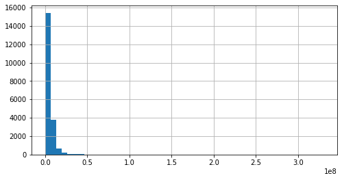

```python
df_filtered['last_price'].hist(bins=50, range=(0, 3.3e8), figsize=(8,4)) # гистограмма по цене
```

```python
df_filtered['rooms'].describe() #статистика по комнатам
```

```
count    20294.000000
mean         2.009461
std          1.006855
min          0.000000
25%          1.000000
50%          2.000000
75%          3.000000
max          9.000000
Name: rooms, dtype: float64
```

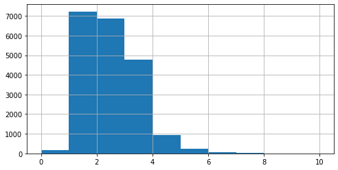

```python
df_filtered['rooms'].hist(bins=10, range=(0, 10), figsize=(8,4)) # гистограмма по количеству комнат
```

```python
df_filtered['ceiling_height'].describe() #статистика по высоте потолка
```

```
count    20294.000000
mean         2.687541
std          0.191583
min          2.500000
25%          2.600000
50%          2.650000
75%          2.700000
max          4.000000
Name: ceiling_height, dtype: float64
```

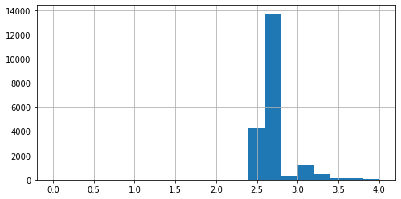

```python
df_filtered['ceiling_height'].hist(bins=20, range=(0, 4), figsize=(8,4)) # гистограмма по высоте потолка
```

```python
df_filtered['days_exposition'].describe() # статистика по количеству дней продажи
```

```
count    20294.000000
mean       180.264364
std        219.169582
min          2.000000
25%         45.000000
50%         95.000000
75%        230.000000
max       1572.000000
Name: days_exposition, dtype: float64
```

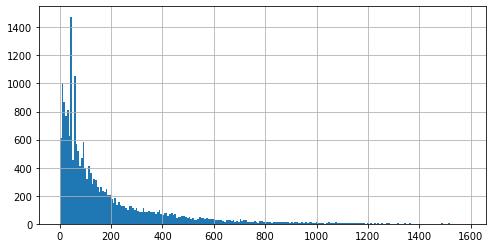

```python
df_filtered['days_exposition'].hist(bins=230, range=(0, 1580), figsize=(8,4)) # гистограмма по количеству дней продажи
```

1. Изучим какие факторы больше всего влияют на стоимость квартиры. Для этого посмотрим графики зависимости цены от разных параметров

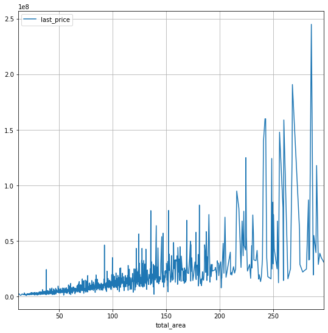

```python
df_filtered.pivot_table(index='total_area', values ='last_price').plot(grid=True, figsize=(9,9)) # зависимость цены от площади
```

В основном график растущий: чем больше площадь тем выше цена. Но есть выбивающиеся значения из этой закономерности значения.

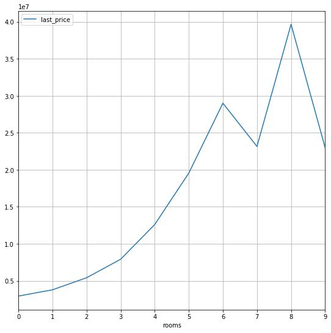

```python
df_filtered.pivot_table(index='rooms', values ='last_price').plot(grid=True, figsize=(9,9)) # зависимость цены от количества комнат
```

В основом тенденция: чем больше комнат тем выше цена, но когда число комнат становиться больше 8, то количество комнат уже не является определяющей для цены квартиры.

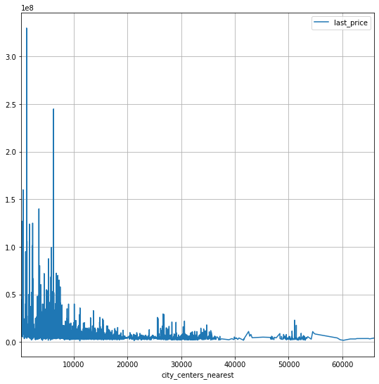

```python
df_filtered.pivot_table(index='city_сenters_nearest', values ='last_price').plot(grid=True, figsize=(9,9)) # зависимость цены от удаленности к центру
```

Из графика видно, что чем ближе к центру города, тем выше цена за квартиру.

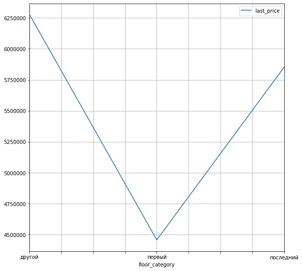

```python
df_filtered.pivot_table(index='floor_category', values ='last_price').plot(grid=True, figsize=(9,9)) # зависимость цены от этажа
```

Цена квартиры будет ниже, чем цена квартиры на последнем или другом этаже.

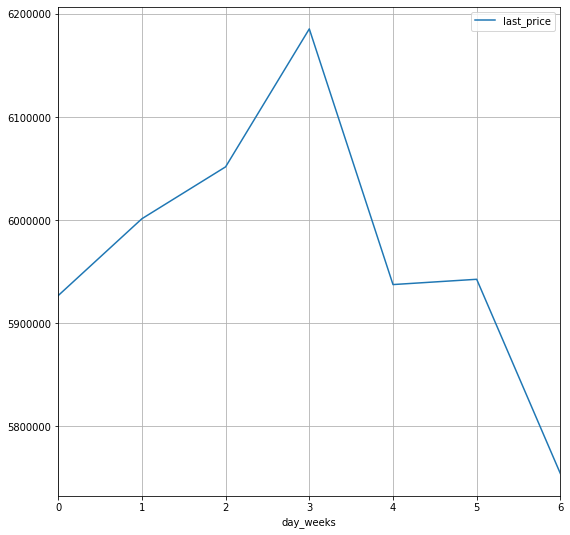

```python
df_filtered.pivot_table(index='day_weeks', values ='last_price').plot(grid=True, figsize=(9,9)) # зависимость цены от дня недели, в котором было размещено объявление
```

Очень интересный график: получается квартиры размещенные по воскресеньям имели более низкую цену, чем квартиры размещенные на продажу в четверг. Посмотрим, а какие квартиры быстрее продавались выставленные в субботу или воскресенье?

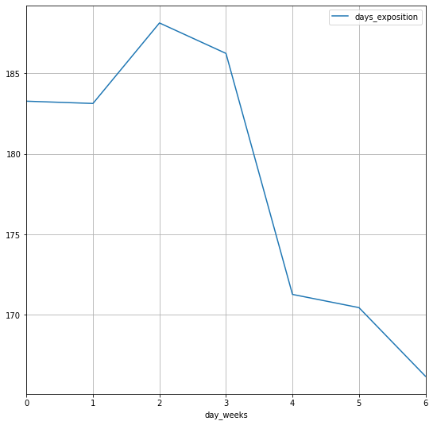

```python
df_filtered.pivot_table(index='day_weeks', values ='days_exposition').plot(grid=True, figsize=(9,9)) # зависимость длительности продажи квартиры от дня недели, в котором было размещено объявление
```

Судя по графику продавались квартиры быстрее выставленные в воскресенье, что в общем-то логично, потому что цена по воскресеньям ниже.

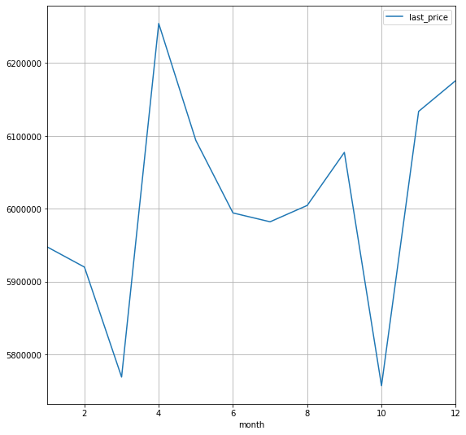

```python
df_filtered.pivot_table(index='month', values ='last_price').plot(grid=True, figsize=(9,9)) # зависимость цены от месяца, в котором было размещено объявление
```

Видим, что март и октябрь были лучшими месяцами для покупки квартир. Цена на квартиры была ниже всего, в отличие от апреля и декабря.

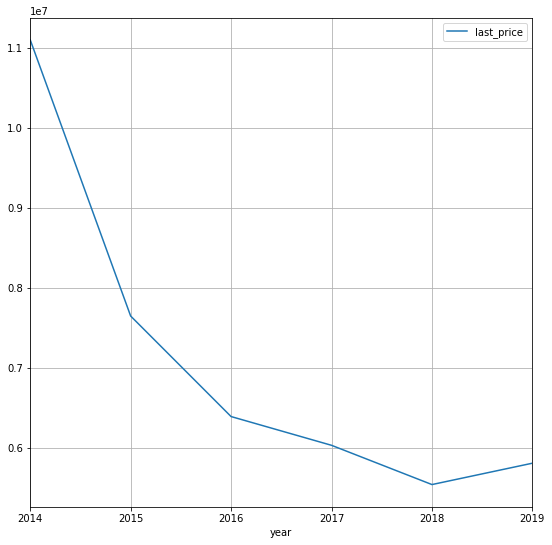

```python
df_filtered.pivot_table(index='year', values ='last_price').plot(grid=True, figsize=(9,9)) # зависимость цены от года, в котором было размещено объявление
```

Из графика видно, что с с 2014 по 2018 год была тенденция к снижению количества дорогого жилья, продавали только дешевые квартиры.

```python
df.columns
```

```
Index(['total_images', 'last_price', 'total_area', 'first_day_exposition',
       'rooms', 'ceiling_height', 'floors_total', 'living_area', 'floor',
       'is_apartment', 'studio', 'open_plan', 'kitchen_area', 'balcony',
       'locality_name', 'airports_nearest', 'city_сenters_nearest',
       'parks_around_3000', 'parks_nearest', 'ponds_around_3000',
       'ponds_nearest', 'days_exposition', 'm2_price', 'day_weeks', 'month',
       'year', 'floor_category', 'area_living_total', 'area_kitchen_total'],
      dtype='object')
```

```python
display(df_filtered[['last_price', 'm2_price', 'total_area', 'rooms', 'city_сenters_nearest']].corr())
```

|  | last_price | m2_price | total_area | rooms | city_сenters_nearest |
| --- | --- | --- | --- | --- | --- |
| last_price | 1.000000 | 0.780157 | 0.668600 | 0.392324 | -0.253388 |
| m2_price | 0.780157 | 1.000000 | 0.272010 | 0.019979 | -0.334626 |
| total_area | 0.668600 | 0.272010 | 1.000000 | 0.785074 | -0.241677 |
| rooms | 0.392324 | 0.019979 | 0.785074 | 1.000000 | -0.177643 |
| city_сenters_nearest | -0.253388 | -0.334626 | -0.241677 | -0.177643 | 1.000000 |

1. Выберем 10 населенных пунктов с наибольшим количество объявлений и посчитаем среднюю стоимость квадратного метра в этих городах

```python
display(top_10.head(10))
```

```
locality_name
Санкт-Петербург      15721
посёлок Мурино         522
посёлок Шушары         440
Всеволожск             398
Пушкин                 369
Колпино                338
посёлок Парголово      327
Гатчина                307
деревня Кудрово        299
Выборг                 237
Name: locality_name, dtype: int64
```

```python
top = ['санкт-петербург', 'посёлок мурино', 'посёлок шушары', 'всеволожск', 'пушкин', 'колпино', 'посёлок парголово', 'гатчина', 'деревня кудрово', 'выборг']
```

```python
top_10_metr = df.query('locality_name in @top') #срез данных по названиям 10 населенных пунктов
#top_10_metr.head()
top_1 = top_10_metr.groupby('locality_name')['m2_price'].mean().sort_values(ascending = False) # сортировка названию с выводом средней цены за метр квадратный
display(top_1)
```

```
locality_name
санкт-петербург      114848.565231
пушкин               103125.373984
деревня кудрово       92473.086957
посёлок парголово     90175.489297
посёлок мурино        85751.733716
посёлок шушары        78676.904545
колпино               75424.150888
гатчина               68745.693811
всеволожск            68654.007538
выборг                58141.489451
Name: m2_price, dtype: float64
```

```python
#top_10_metr = df.groupby('locality_name')['m2_price'].mean().sort_values(ascending = False)
#display(top_10_metr.head(10))
```

Добавим столбец "расстояние до центра в километрах"

```python
df_filtered['сenters_nearest_km'] = (df_filtered['city_сenters_nearest'] / 1000).round() #расстояние до центра в километрах
```

```python
df_filtered.head()
```

|  | total_images | last_price | total_area | first_day_exposition | rooms | ceiling_height | floors_total | living_area | floor | is_apartment | ... | ponds_nearest | days_exposition | m2_price | day_weeks | month | year | floor_category | area_living_total | area_kitchen_total | сenters_nearest_km |
| --- | --- | --- | --- | --- | --- | --- | --- | --- | --- | --- | --- | --- | --- | --- | --- | --- | --- | --- | --- | --- | --- |
| 1 | 7 | 3350000 | 40.4 | 2018-12-04 | 1 | 2.65 | 11 | 18.6 | 1 | False | ... | NaN | 81 | 82920 | 1 | 12 | 2018 | первый | 0.460396 | 0.272277 | 19.0 |
| 2 | 10 | 5196000 | 56.0 | 2015-08-20 | 2 | 2.65 | 5 | 34.3 | 4 | False | ... | 574 | 558 | 92785 | 3 | 8 | 2015 | другой | 0.612500 | 0.148214 | 14.0 |
| 3 | 0 | 64900000 | 159.0 | 2015-07-24 | 3 | 2.65 | 14 | NaN | 9 | False | ... | 234 | 424 | 408176 | 4 | 7 | 2015 | другой | NaN | NaN | 7.0 |
| 4 | 2 | 10000000 | 100.0 | 2018-06-19 | 2 | 3.03 | 14 | 32.0 | 13 | False | ... | 48 | 121 | 100000 | 1 | 6 | 2018 | другой | 0.320000 | 0.410000 | 8.0 |
| 5 | 10 | 2890000 | 30.4 | 2018-09-10 | 1 | 2.65 | 12 | 14.4 | 5 | False | ... | NaN | 55 | 95065 | 0 | 9 | 2018 | другой | 0.473684 | 0.299342 | NaN |

5 rows × 30 columns

```python
df_filtered['price_km'] = df_filtered['last_price'] / df_filtered['сenters_nearest_km'] # добавим столбец стоимость килdf_filteredометра
```

```python
df_spb = df_filtered.query('locality_name == "санкт-петербург"') #срез данных по городу Санкт-Петербург
display(df_spb.head())
```

|  | total_images | last_price | total_area | first_day_exposition | rooms | ceiling_height | floors_total | living_area | floor | is_apartment | ... | days_exposition | m2_price | day_weeks | month | year | floor_category | area_living_total | area_kitchen_total | сenters_nearest_km | price_km |
| --- | --- | --- | --- | --- | --- | --- | --- | --- | --- | --- | --- | --- | --- | --- | --- | --- | --- | --- | --- | --- | --- |
| 2 | 10 | 5196000 | 56.0 | 2015-08-20 | 2 | 2.65 | 5 | 34.3 | 4 | False | ... | 558 | 92785 | 3 | 8 | 2015 | другой | 0.612500 | 0.148214 | 14.0 | 3.711429e+05 |
| 3 | 0 | 64900000 | 159.0 | 2015-07-24 | 3 | 2.65 | 14 | NaN | 9 | False | ... | 424 | 408176 | 4 | 7 | 2015 | другой | NaN | NaN | 7.0 | 9.271429e+06 |
| 4 | 2 | 10000000 | 100.0 | 2018-06-19 | 2 | 3.03 | 14 | 32.0 | 13 | False | ... | 121 | 100000 | 1 | 6 | 2018 | другой | 0.320000 | 0.410000 | 8.0 | 1.250000e+06 |
| 9 | 18 | 5400000 | 61.0 | 2017-02-26 | 3 | 2.50 | 9 | 43.6 | 7 | False | ... | 289 | 88524 | 6 | 2 | 2017 | другой | 0.714754 | 0.106557 | 15.0 | 3.600000e+05 |
| 10 | 5 | 5050000 | 39.6 | 2017-11-16 | 1 | 2.67 | 12 | 20.3 | 3 | False | ... | 137 | 127525 | 3 | 11 | 2017 | другой | 0.512626 | 0.214646 | 14.0 | 3.607143e+05 |

5 rows × 31 columns

```python
df_spb.groupby('сenters_nearest_km')['m2_price'].mean()
```

```
сenters_nearest_km
0.0     228349.833333
1.0     157689.830189
2.0     149410.876494
3.0     116071.825926
4.0     128441.012478
5.0     137022.314060
6.0     145771.082840
7.0     150265.848837
8.0     122419.161100
9.0     110800.442495
10.0    111255.658188
11.0    106427.906887
12.0    106066.038380
13.0    106521.374808
14.0    103093.681289
15.0    102255.883994
16.0     99019.960289
17.0     95486.730623
18.0     95253.977876
19.0     98709.056338
20.0    100888.815789
21.0     91336.414894
22.0     90259.889535
23.0     89829.812500
24.0     85736.461538
25.0     91531.038462
26.0     89340.865385
27.0    132115.000000
28.0     81161.571429
29.0     76238.000000
Name: m2_price, dtype: float64
```

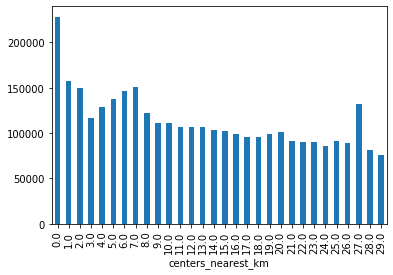

```python
df_spb.groupby('сenters_nearest_km')['m2_price'].mean().plot(kind='bar') # вывод графика зависимости цены квадратного метра от удаленности от центра
```

Центром города можно считать зону в радиусе 2 километров.

```python
df_spb_center = df_spb[df_spb['сenters_nearest_km'] <= 2] #срез по квартирам в центре Санкт-Петербурга
```

```python
df_spb_center.head()
```

|  | total_images | last_price | total_area | first_day_exposition | rooms | ceiling_height | floors_total | living_area | floor | is_apartment | ... | days_exposition | m2_price | day_weeks | month | year | floor_category | area_living_total | area_kitchen_total | сenters_nearest_km | price_km |
| --- | --- | --- | --- | --- | --- | --- | --- | --- | --- | --- | --- | --- | --- | --- | --- | --- | --- | --- | --- | --- | --- |
| 24 | 8 | 6500000 | 97.2 | 2015-10-31 | 2 | 2.65 | 3 | 46.5 | 1 | False | ... | 265 | 66872 | 5 | 10 | 2015 | первый | 0.478395 | 0.201646 | 2.0 | 3250000.0 |
| 213 | 11 | 8700000 | 111.4 | 2016-10-10 | 4 | 3.10 | 4 | 73.2 | 2 | False | ... | 791 | 78096 | 0 | 10 | 2016 | другой | 0.657092 | 0.126571 | 1.0 | 8700000.0 |
| 239 | 16 | 22000000 | 119.0 | 2017-02-16 | 3 | 3.50 | 5 | 56.0 | 3 | False | ... | 77 | 184873 | 3 | 2 | 2017 | другой | 0.470588 | 0.294118 | 2.0 | 11000000.0 |
| 282 | 17 | 37000000 | 115.0 | 2018-11-15 | 2 | 2.65 | 5 | 65.0 | 2 | False | ... | 158 | 321739 | 3 | 11 | 2018 | другой | 0.565217 | 0.121739 | 2.0 | 18500000.0 |
| 330 | 16 | 7100000 | 50.0 | 2016-04-20 | 3 | 2.65 | 5 | 31.5 | 1 | False | ... | 900 | 142000 | 2 | 4 | 2016 | первый | 0.630000 | 0.100000 | 2.0 | 3550000.0 |

5 rows × 31 columns

```python
df_spb_center['total_area'].describe() # стастистика по площади квартир в центре Санкт-Петербурга
```

```
count    428.000000
mean      98.193271
std       50.154749
min       12.000000
25%       64.225000
50%       85.750000
75%      116.125000
max      297.500000
Name: total_area, dtype: float64
```

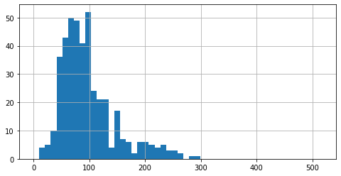

```python
df_spb_center['total_area'].hist(bins=50, range=(0, 517), figsize=(8,4)) # гистограмма площадей квартир в центре города
```

Можно сделать вывод что большинство квартир в центре имеют площадь от 90 до 100 метров.

```python
df_spb_center['last_price'].describe() # стастистика по цене квартир в центре Санкт-Петербурга
```

[output not shown]

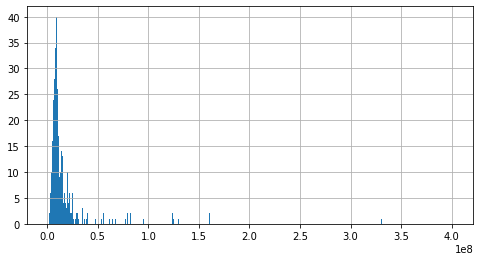

```python
df_spb_center['last_price'].hist(bins=500, range=(0, 4.013000e+08), figsize=(8,4)) # гистограмма цены квартир в центре города
```

```python
df_spb_center['rooms'].describe() # стастистика по количеству комнат квартир в центре Санкт-Петербурга
```

```
count    428.000000
mean       3.109813
std        1.373758
min        0.000000
25%        2.000000
50%        3.000000
75%        4.000000
max        8.000000
Name: rooms, dtype: float64
```

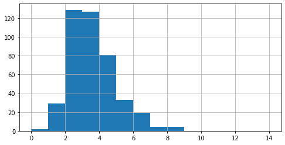

```python
df_spb_center['rooms'].hist(bins=14, range=(0, 14), figsize=(8,4))
```

Большинство квартир вт центре имеют от 2 до 4 комнат. В среднем 3 комнаты.

```python
df_spb_center['ceiling_height'].describe() # стастистика по высоте потолков квартир в центре Санкт-Петербурга
```

```
count    428.000000
mean       3.021472
std        0.384211
min        2.500000
25%        2.650000
50%        3.000000
75%        3.300000
max        4.000000
Name: ceiling_height, dtype: float64
```

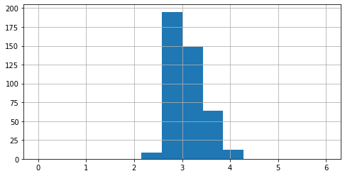

```python
df_spb_center['ceiling_height'].hist(bins=14, range=(0, 6), figsize=(8,4))
```

Большинство квартир в центре имеют высоту потолков от 2,5 до 3 метров.

Проанализируем как число комнат, этаж, удалённость от центра, дата размещения объявления влияют на стоимоть квартир в центре Санкт-Петербурга

```python
df_spb_center.columns
```

```
Index(['total_images', 'last_price', 'total_area', 'first_day_exposition',
       'rooms', 'ceiling_height', 'floors_total', 'living_area', 'floor',
       'is_apartment', 'studio', 'open_plan', 'kitchen_area', 'balcony',
       'locality_name', 'airports_nearest', 'city_сenters_nearest',
       'parks_around_3000', 'parks_nearest', 'ponds_around_3000',
       'ponds_nearest', 'days_exposition', 'm2_price', 'day_weeks', 'month',
       'year', 'floor_category', 'area_living_total', 'area_kitchen_total',
       'сenters_nearest_km', 'price_km'],
      dtype='object')
```

1. Зависимость цены от количества комнат

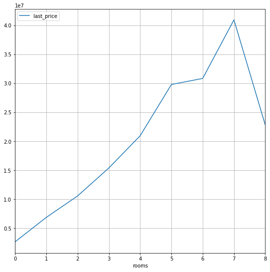

```python
df_spb_center.pivot_table(index='rooms', values ='last_price').plot(grid=True, figsize=(9,9)) # зависимость цены от количества комнат
```

Цена растет от увеличения количества комнат в квартире.

1. Зависимость цены квартиры от этажа

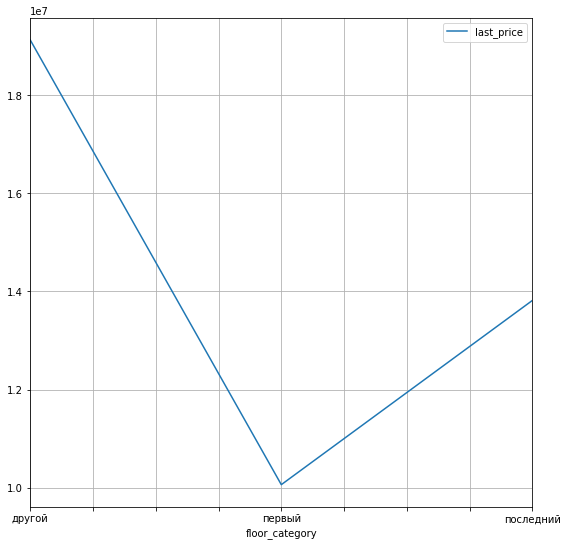

```python
df_spb_center.pivot_table(index='floor_category', values ='last_price').plot(grid=True, figsize=(9,9)) # зависимость цены от этажа
```

Здесь также можно сделать вывод что у квартир на первом этаже цена ниже, чем на последнем и другом.

1. Зависимость цены от удаленности от центра

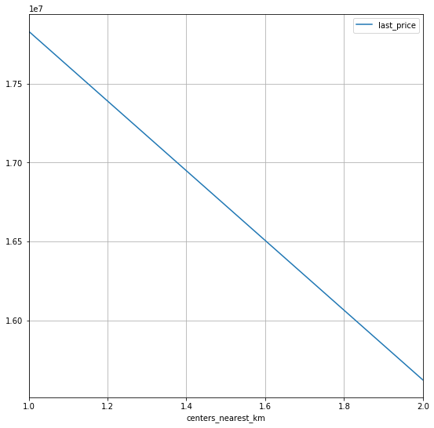

```python
df_spb_center.pivot_table(index='сenters_nearest_km', values ='last_price').plot(grid=True, figsize=(9,9))
```

Стоимость цены квартиры падает с возрастающей удаленностью от центра

1. Зависимость цены от дня недели размещения объявления

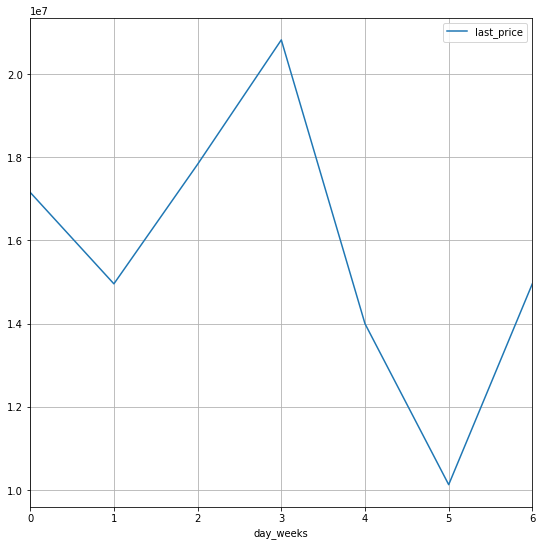

```python
df_spb_center.pivot_table(index='day_weeks', values ='last_price').plot(grid=True, figsize=(9,9))
```

По субботам выставлялись квартиры с более низкой стоимостью.

1. Зависимость цены от месяца размещения объявления

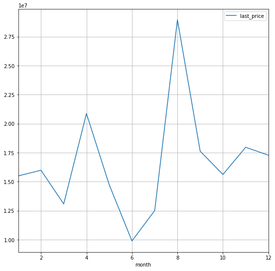

```python
df_spb_center.pivot_table(index='month', values ='last_price').plot(grid=True, figsize=(9,9))
```

В июне выставлялись квартиры на продажу с более низкой стоимостью, в августе с более высокой стоимостью.

1. Зависимость цены от года подачи объявления о продаже квартиры

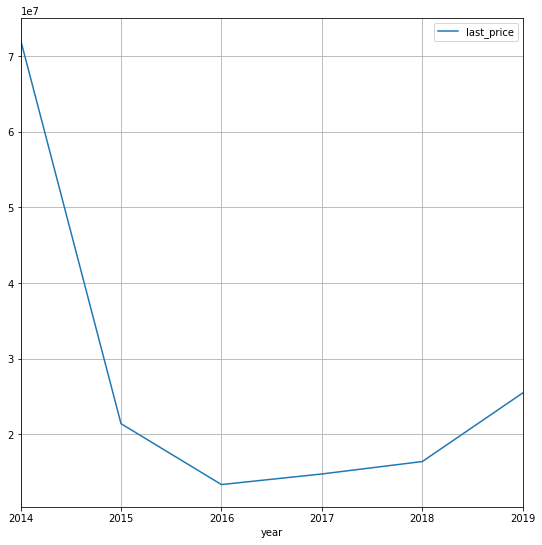

```python
df_spb_center.pivot_table(index='year', values ='last_price').plot(grid=True, figsize=(9,9))
```

В 2014 году выставлялись на продажу квартиры с более высокой стоимостью, и до 2016 года цена продаваемых квартир падала.

## Общий вывод

Считаю, что параметры оценки стоимости жилья, что для центра города Санкт-Петербург, что для всего города в целом одинаковые. На стомость жилья влияет: количество комнат, площадь, этаж и удаленность от центра города.